# Introduction to gadget3: A single stock model

This vignette walks through a script that will generate a gadget3 model, explaining concepts along the way.

Code blocks that make up the gadget3 script are marked in blue, like this:

```r
### Introduction to gadget3: A single stock model
```

When combined they will form a full model, see the appendix for the entire script.

## Gadget3 and the gadget framework

Gadget3 is a marine modelling R package, but it is not in itself an ecosystem model. Instead, it gives you building blocks (or *actions*) that can be assembled to produce as complex model as your situation requires. This can then be converted into other forms, most importantly a TMB objective function or an R function, which can then be optimised and run to generate reporting.

As the name suggests, it’s designed to be a successor to the previous [gadget](https://cran.r-project.org/package=gadget2) modelling framework. The actions currently available are designed to be very similar, if not identical, to the components present in gadget2. If you are familiar with previous versions of gadget then you will find the naming very similar, and translation of old input files to gadget3 can be done in a rote fashion.

Gadget3 is the core part of what is known as the *gadget framework*, a set of packages that are designed to work together to produce ecosystem models.

- gadget3: The core package, assembles ecosystem models from R code
- [MFDB](https://cran.r-project.org/package=mfdb): The data-handling package, to help aggregating & formatting time-series data suitable for using as inputs to your model
- gadgetutils: A set of utilities to help produce an optimised model
- gadgetplots: Tools to produce plots and HTML pages summarising model output
- g3experiments: Additional actions / features not yet ready for inclusion in gadget3
- modelwizard: A GUI package to assist in building in model scripts, both for gadget3 and SS3

These packages are loosely coupled; you do not need everything installed to create a gadget3 model. However, when they will prove useful it will be mentioned here.

The `gadget3` package can be installed via. CRAN:

```r
install.packages('gadget3')
```

The full set of packages can be installed with:

```r
install.packages('MFDB')
remotes::install_github('gadget-framework/gadgetutils')
remotes::install_github('gadget-framework/gadgetplots')
remotes::install_github('gadget-framework/g3experiments')
```

## Creating a (single species) model

As opposed gadget2 and other modelling frameworks, there is no input data format. Instead, the model configuration is written as an R script. This document will walk through the parts of a model script for a single-species model, introducing concepts along the way.

The first step in any script is to load `gadget3`. We will also use `dplyr` when formatting input data:

```r
library(gadget3)
library(dplyr)
```

### Actions

A gadget3 model is defined as a list of *actions*. *Actions* are snippets of code that define processes in a model.

To start with, we will add the `g3a_time()` to our list of actions:

```r
actions <- list()

# Create time definitions ####################

actions_time <- list(
  g3a_time(
    1990L, 2023L,
    step_lengths = c(3L, 3L, 3L, 3L)),
  NULL)

actions <- c(actions, actions_time)
```

This acts as timekeeping for our model, starting in year 1990 and progressing until 2023. Each year will have 4 time steps in, of equal length.

As a convention, we build up an `actions` array of everything required, allowing sections to be added/removed as necessary.

Ultimately, this list will be converted to either R or TMB code with with `g3_to_r()` or `g3_to_tmb()` respectively. We can try this already with our time action, and generate a function that will count years & steps:

```r
g3_to_r(actions_time)
```

```
function (param = parameter_template)
{
    if (is.data.frame(param)) {
        param_lower <- structure(param$lower, names = param$switch)
        param_upper <- structure(param$upper, names = param$switch)
        logarithmic <- grepl("(^|:)LOG(:|$)", param$type)
        param$value[logarithmic] <- lapply(param[logarithmic,
            "value"], log)
        param_lower[logarithmic] <- lapply(param_lower[logarithmic],
            log)
        param_upper[logarithmic] <- lapply(param_upper[logarithmic],
            log)
        param <- structure(param$value, names = param$switch)
    }
    else {
        param_lower <- lapply(param, function(x) NA)
        param_upper <- lapply(param, function(x) NA)
    }
    stopifnot("retro_years" %in% names(param))
    assert_msg <- function(expr, message) {
        if (isFALSE(expr)) {
            warning(message)
            return(TRUE)
        }
        return(FALSE)
    }
    cur_time <- -1L
    stopifnot("project_years" %in% names(param))
    project_years <- param[["project_years"]]
    cur_year <- 0L
    start_year <- 1990L
    step_count <- length(step_lengths)
    cur_year_projection <- FALSE
    end_year <- 2023L
    cur_step <- 0L
    cur_step_size <- step_lengths[[1]]/12
    cur_step_final <- FALSE
    as_integer <- as.integer
    retro_years <- param[["retro_years"]]
    total_steps <- length(step_lengths) * (end_year - as_integer(retro_years) -
```

[output cut: 12 more lines]

```
                return(NaN)
            cur_year <- start_year + (cur_time%/%step_count)
            cur_year_projection <- cur_year > end_year - param[["retro_years"]]
            cur_step <- (cur_time%%step_count) + 1L
            cur_step_size <- step_lengths[[cur_step]]/12
            cur_step_final <- cur_step == step_count
        }
        {
            if (cur_time > total_steps)
                return(nll)
        }
    }
}
<bytecode: 0x559eb4ea31e8>
<environment: 0x559eb5a19038>
```

```r
g3_to_tmb(actions_time)
```

```
// Model generated with gadget3 0.14-0
#include <TMB.hpp>
#include <numeric>


#ifndef TYPE_IS_SCALAR
#ifdef TMBAD_FRAMEWORK
#define TYPE_IS_SCALAR(TestT) typename = std::enable_if_t<std::is_same<TestT, int>::value || std::is_same<TestT, double>::value || std::is_same<TestT, TMBad::global::ad_aug>::value>
#endif // TMBAD_FRAMEWORK
#ifdef CPPAD_FRAMEWORK
#define TYPE_IS_SCALAR(TestT) typename = std::enable_if_t<std::is_same<TestT, int>::value || std::is_same<TestT, double>::value || std::is_same<TestT, CppAD::AD<double>>::value || std::is_same<TestT, CppAD::AD<CppAD::AD<double>>>::value || std::is_same<TestT, CppAD::AD<CppAD::AD<CppAD::AD<double>>>>…
#endif // CPPAD_FRAMEWORK
#endif // TYPE_IS_SCALAR



template<class Type>
Type objective_function<Type>::operator() () {
    DATA_SCALAR(reporting_enabled); DATA_UPDATE(reporting_enabled);
    PARAMETER(retro_years);
    auto assert_msg = [](bool expr, std::string message) -> bool {
    if (!expr) { Rf_warning(message.c_str()); return TRUE; }
    return FALSE;
};
    int cur_time = -1;
    PARAMETER(project_years);
    int cur_year = 0;
    int start_year = 1990;
    vector<int> step_lengths(4); step_lengths.setConstant(3);
    auto step_count = (int)(step_lengths).size();
    int cur_year_projection = false;
    int end_year = 2023;
    int cur_step = 0;
    auto cur_step_size = step_lengths ( 0 ) / (double)(12);
    int cur_step_final = false;
    auto as_integer = [](Type v) -> int {
    return std::floor(asDouble(v));
};
    auto total_steps = (int)(step_lengths).size()*(end_year - as_integer(retro_years) - start_year + as_integer(project_years)) + (int)(step_lengths).size() - 1;
    Type nll = (double)(0);
```

[output cut: 9 more lines]

```
                return NAN;
            }
            cur_year = start_year + ((int) std::floor(asDouble((cur_time) / ((double) step_count))));
            cur_year_projection = cur_year > end_year - retro_years;
            cur_step = (cur_time % step_count) + 1;
            cur_step_size = step_lengths ( cur_step - 1 ) / (double)(12);
            cur_step_final = cur_step == step_count;
        }
        {
            if ( cur_time > total_steps ) {
                return nll;
            }
        }
    }
}
```

### Stocks

After actions, the other key concept in a gadget3 model is a *stock*. These are the means to describe populations within your model. For simpler scenarios such as here, stocks map directly to a species. However, more complicated models may have one stock per-maturation-stage, sex or both.

We define a stock with the `g3_stock()` and associated `g3s_*` functions, for example:

```r
area_names <- g3_areas(c('IXa', 'IXb'))

# Create stock definition for fish ####################
fish <- g3_stock("fish", seq(10, 100, 10)) |>
  g3s_livesonareas(area_names["IXa"]) |>
  g3s_age(1L, 5L)
```

Here we define a stock called “fish” with length bins 10..100, then add an area to live in & 5 age bins.

Ultimately, the stock functions define the structure of the arrays that will hold the state of that stock within gadget3. We can use `g3_stock_instance()` to see an example of the array used:

```r
# aperm() re-orders dimensions for more compact printing
aperm(g3_stock_instance(fish, 0), c(1,3,2))
```

```
## , , area = IXa
##
##          age
## length    age1 age2 age3 age4 age5
##   10:20      0    0    0    0    0
##   20:30      0    0    0    0    0
##   30:40      0    0    0    0    0
##   40:50      0    0    0    0    0
##   50:60      0    0    0    0    0
##   60:70      0    0    0    0    0
##   70:80      0    0    0    0    0
##   80:90      0    0    0    0    0
##   90:100     0    0    0    0    0
##   100:Inf    0    0    0    0    0
```

For example, the abundance and mean weight of the stock will be stored in one of these arrays within the model.

### Stock actions

Now we have a stock, we can add apply population dynamics *actions*, and save them in the `actions` array from earlier:

```r
actions_fish <- list(
  g3a_growmature(fish, g3a_grow_impl_bbinom(
    maxlengthgroupgrowth = 4L)),
  g3a_naturalmortality(fish),
  g3a_initialconditions_normalcv(fish),
  g3a_renewal_normalcv(fish,
    run_step = 2),
  g3a_age(fish),
  NULL)

actions_likelihood_fish <- list(
  g3l_understocking(list(fish), nll_breakdown = TRUE),
  NULL)

actions <- c(actions, actions_fish, actions_likelihood_fish)
```

Each of these `g3a_*` actions will have a 1:1 parallel with gadget2 stockfile components, so if you are familiar with these config files will do what you expect.

For each action you can click through to the reference to get more information on what it does, but in summary we have defined:

- `g3a_growmature()`: The growth model
- `g3a_naturalmortality()`: Natural mortality of our stock
- `g3a_initialconditions_normalcv()`: Initial recruitment, defining numbers & mean weights for the start of the model
- `g3a_renewal_normalcv()`: Recruitment occuring every spring (`run_step = 2`), independent of stock status
- `g3a_age()`: Move fish through age groups at the end of a year
- `g3l_understocking()`: A penalty applied to the likelihood used to prevent more fish being eaten/fished than is available.

There are more actions available besides these, for instance `g3a_spawn()` can be used for recruitment dependent on stock size instead of `g3a_renewal_normalcv()`. For a full list, see `??gadget3::"G3 action"` or the package reference index.

Likelihood actions are actions that will sum their output into the model’s overall likelihood score, analogous to gadget2’s [likelihood components](https://gadget-framework.github.io/gadget2/userguide/chap-like.html).

The order of these actions as we have defined them is not preserved. When a model runs, the steps will not happen in the above order, they will be re-ordered to match the standard action order, see `?g3_action_order`.

#### Model parameters

The definition above should look quite barren, bar `maxlengthgroupgrowth` we have not provided any figures for the stock dynamics.

The defaults for all actions define *model parameters* that can be set as fixed values or optimised later, rather than baking them into the model.

For instance, we can see that `g3a_naturalmortality()` creates a parameter for `M` by default:

```r
head(g3a_naturalmortality)
```

```
##
## 1 function (stock, mortality_f = g3a_naturalmortality_exp(), run_f = TRUE,
## 2     run_at = g3_action_order$naturalmortality)
## 3 {
## 4     stopifnot(g3_is_stock(stock))
## 5     out <- new.env(parent = emptyenv())
## 6     action_name <- unique_action_name()
```

```r
head(g3a_naturalmortality_exp)
```

```
##
## 1 function (param_f = g3_parameterized("M", by_stock = by_stock,
## 2     by_age = TRUE), by_stock = TRUE, action_step_size_f = ~cur_step_size)
## 3 {
## 4     f_substitute(~exp(-(param_f) * action_step_size_f), list(param_f = param_f,
## 5         action_step_size_f = action_step_size_f))
## 6 }
```

Without any arguments, we use `g3a_naturalmortality_exp()`, which sets `M` to be `g3_parameterized("M", by_stock = TRUE, by_age = TRUE)`. This tells gadget3 that a parameter `M` should be expected by the model, that will both be broken down by stock (i.e. will include the name of our stock), and each age within that stock.

We can define a model with just `g3a_time()` and `g3a_initialconditions_normalcv()` to see the end result. To be able to run the function you need to provide a list of parameter values, the format of this list is defined by the attached *parameter template*:

```r
simple_actions <- list(
    g3a_time(1990, 1991),
    g3a_initialconditions_normalcv(fish))
simple_fn <- g3_to_r(c(simple_actions, list(
    g3a_report_detail(simple_actions) )))

params <- attr(simple_fn, 'parameter_template')
unlist(params)
```

```
##      retro_years        fish.Linf           fish.K          fish.t0
##              0.0              1.0              1.0              0.0
##       fish.lencv fish.init.scalar      fish.init.1      fish.init.2
##              0.1              1.0              1.0              1.0
##      fish.init.3      fish.init.4      fish.init.5         fish.M.1
##              1.0              1.0              1.0              0.0
##         fish.M.2         fish.M.3         fish.M.4         fish.M.5
##              0.0              0.0              0.0              0.0
##           init.F           recage      fish.walpha       fish.wbeta
##              0.0              0.0              0.0              0.0
##    report_detail    project_years
##              1.0              0.0
```

`g3a_report_detail()` adds standard reporting to our model, we will cover it’s use later.

We can fill in these values and run the model:

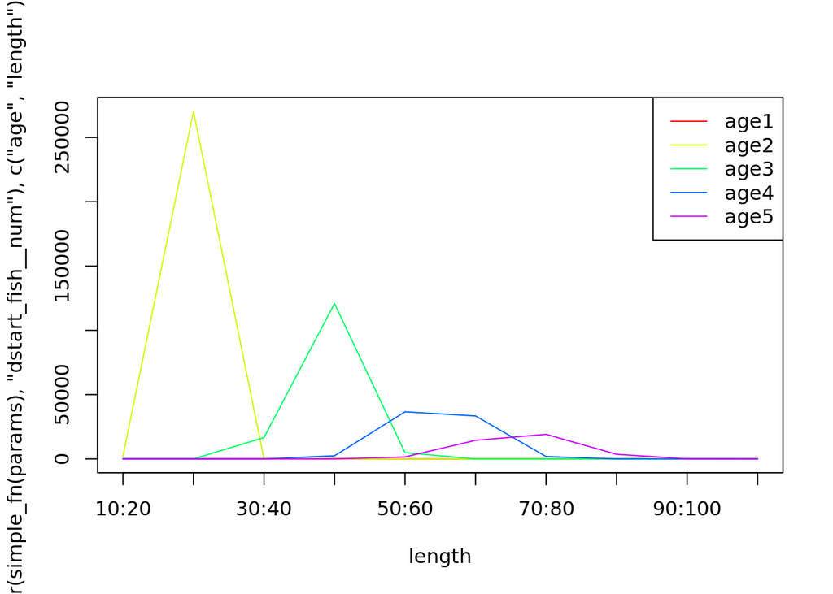

```r
params$fish.init.scalar <- 10
params$fish.init.1 <- 10
params$fish.init.2 <- 10
params$fish.init.3 <- 10
params$fish.init.4 <- 10
params$fish.init.5 <- 10
params$fish.M.1 <- 0.15
params$fish.M.2 <- 0.15
params$fish.M.3 <- 0.15
params$fish.M.4 <- 0.15
params$fish.M.5 <- 0.15
params$init.F <- 0.5
params$recage <- 0
params$fish.Linf <- max(g3_stock_def(fish, "midlen"))
params$fish.K <- 0.3
params$fish.t0 <- g3_stock_def(fish, "minage") - 0.8
params$fish.lencv <- 0.1
params$report_detail <- 1

# Run model and pull out final abundance from the result
g3_array_plot(g3_array_agg(
    attr(simple_fn(params), "dstart_fish__num"),
    c('age', 'length'),
    time = "1990-01"))
```

Altering K results in corresponding changes to the stock structure:

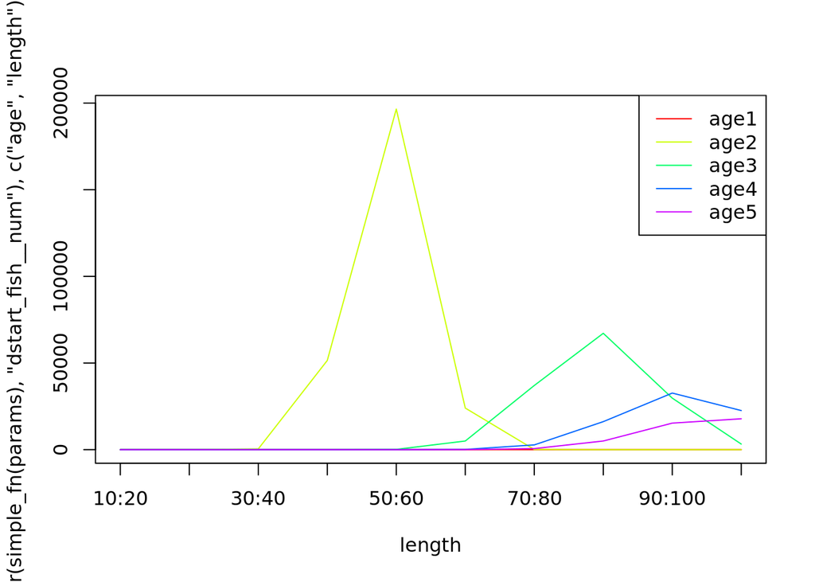

```r
params$fish.K <- 0.9
g3_array_plot(g3_array_agg(
    attr(simple_fn(params), "dstart_fish__num"),
    c('age', 'length'),
    time = "1990-01"))
```

### Fleet actions

Fleets in gadget3 are modelled as stock objects, which predate on their target stocks.

To define a fleet, we need to introduce historical data into the model. In our case we will generate random data, but the aggretation steps would apply regardless.

#### Landings data

```r
# Fleet data for f_surv #################################

# Landings data: For each year/step/area
expand.grid(year = 1990:2023, step = 2, area = 'IXa') |>
    # Generate a random total landings by weight
    mutate(weight = rnorm(n(), mean = 1000, sd = 100)) |>
    # Assign result to landings_f_surv
    identity() -> landings_f_surv
```

Here we use `expand.grid()` to generate a `data.frame()` with all possible *year*/*step*/*area* cominations. We then use `dplyr::mutate()` to add a *weight* column to this table, using `rnorm()` to generate random numbers distributed about a mean.

The `identity()` function is a do-nothing function that passes through the input. We use this to move the assignment onto it’s own line.

The end result is a `data.frame()` of total biomass figures:

```r
landings_f_surv
```

```
##    year step area    weight
## 1  1990    2  IXa  943.9524
## 2  1991    2  IXa  976.9823
## 3  1992    2  IXa 1155.8708
## 4  1993    2  IXa 1007.0508
## 5  1994    2  IXa 1012.9288
## 6  1995    2  IXa 1171.5065
## 7  1996    2  IXa 1046.0916
## 8  1997    2  IXa  873.4939
## 9  1998    2  IXa  931.3147
## 10 1999    2  IXa  955.4338
## 11 2000    2  IXa 1122.4082
## 12 2001    2  IXa 1035.9814
## 13 2002    2  IXa 1040.0771
## 14 2003    2  IXa 1011.0683
```

[output cut: 20 more lines]

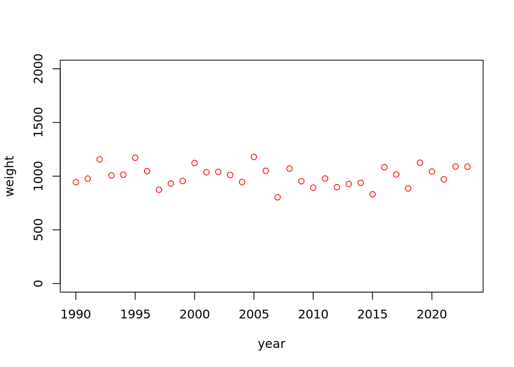

```r
plot(landings_f_surv[c('year', 'weight')], ylim = c(0, 2000), col = "red")
```

Note that we haven’t provided data for all years/steps, as we’ll assume this fleet only works in spring. For more information on how this works, see `vignette("incorporating-observation-data")`.

#### Length distribution data

Next we generate some length-distribution data:

```r
# Length distribution data: Randomly generate 100 samples in each year/step/area
expand.grid(year = 1990:2023, step = 2, area = 'IXa', length = rep(NA, 100)) |>
  # Generate random lengths for these samples
  mutate(length = rnorm(n(), mean = 50, sd = 20)) |>
  # Save unagggregated data into ldist_f_surv.raw
  identity() -> ldist_f_surv.raw

# Aggregate .raw data
ldist_f_surv.raw |>
  # Group into length bins
  group_by(
      year = year,
      step = step,
      length = cut(length, breaks = c(seq(0, 80, 20), Inf), right = FALSE) ) |>
  # Report count in each length bin
  summarise(number = n(), .groups = 'keep') |>
  # Save into ldist_f_surv
  identity() -> ldist_f_surv
```

```r
head(ldist_f_surv.raw)
```

```
##   year step area   length
## 1 1990    2  IXa 66.43162
## 2 1991    2  IXa 63.77281
## 3 1992    2  IXa 61.07835
## 4 1993    2  IXa 48.76177
## 5 1994    2  IXa 43.88075
## 6 1995    2  IXa 42.39058
```

We next use `group_by()` and `cut()` to aggregate by year, step & length bins. `cut()` is responsible for binning continuous data. We can see what it does by running for single values:

```r
cut(c(50), breaks = c(seq(0, 80, 20), Inf), right = FALSE)
```

```
## [1] [40,60)
## Levels: [0,20) [20,40) [40,60) [60,80) [80,Inf)
```

Note that we add `Inf` to the end of the list of breaks, to create a plus-group. We also specify `right = FALSE` so that the groups are closed on the left.

Also note that our breaks aren’t the same as our stock definition, this is allowed and gadget3 will re-aggregate the model data to match. For more information on how this works, see `vignette("incorporating-observation-data")`.

Finally, summarise counts the number in each group and puts the result into a *number* column. The end result looks like:

```r
summary(ldist_f_surv)
```

```
##       year           step        length       number
##  Min.   :1990   Min.   :2   [0,20)  :34   Min.   : 1.00
##  1st Qu.:1998   1st Qu.:2   [20,40) :34   1st Qu.: 5.00
##  Median :2006   Median :2   [40,60) :34   Median :18.00
##  Mean   :2006   Mean   :2   [60,80) :34   Mean   :18.18
##  3rd Qu.:2015   3rd Qu.:2   [80,Inf):34   3rd Qu.:27.00
##  Max.   :2023   Max.   :2   NA's    :17   Max.   :50.00
```

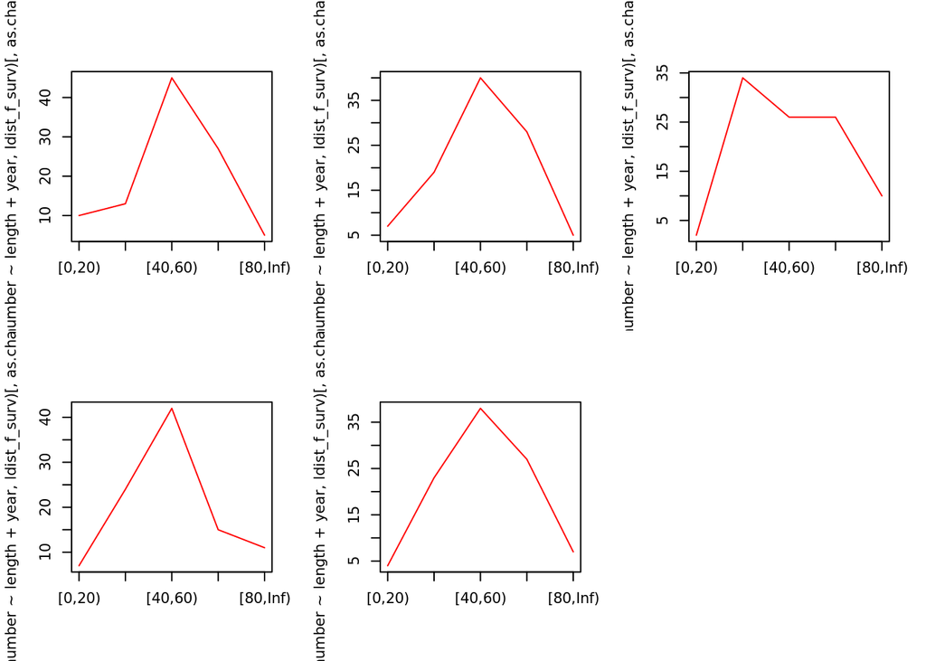

```r
years <- 1990:1994
par(mfrow=c(2, ceiling(length(years) / 2)))
for (y in years) g3_array_plot(xtabs(number ~ length + year, ldist_f_surv)[,as.character(y)])
```

#### Age-length distribution data

Finally, we can apply the same techniques to generate and aggregate age-length data:

```r
# Assume 100 * 100 samples in each year/step/area
expand.grid(year = 1990:2023, step = 2, area = 'IXa', age = rep(NA, 100), length = rep(NA, 100)) |>
  # Generate random whole numbers for age
  mutate(age = floor(runif(n(), min = 1, max = 5))) |>
  # Generate random lengths for these samples
  mutate(length = rnorm(n(), mean = 30 + age * 10, sd = 20)) |>
  # Group into length/age bins
  group_by(
      year = year,
      step = step,
      age = age,
      length = cut(length, breaks = c(seq(0, 80, 20), Inf), right = FALSE) ) |>
  # Report count in each length bin
  summarise(number = n(), .groups = 'keep') ->
  aldist_f_surv
```

The end result is a `data.frame()` with *year*/*step*/*age*/*length*/*number*:

```r
summary(aldist_f_surv)
```

```
##       year           step        age             length        number
##  Min.   :1990   Min.   :2   Min.   :1.000   [0,20)  :136   Min.   :   1.0
##  1st Qu.:1998   1st Qu.:2   1st Qu.:1.000   [20,40) :136   1st Qu.:  62.0
##  Median :2006   Median :2   Median :2.000   [40,60) :136   Median : 349.0
##  Mean   :2006   Mean   :2   Mean   :2.476   [60,80) :136   Mean   : 423.4
##  3rd Qu.:2015   3rd Qu.:2   3rd Qu.:3.000   [80,Inf):136   3rd Qu.: 803.5
##  Max.   :2023   Max.   :2   Max.   :4.000   NA's    :123   Max.   :1037.0
```

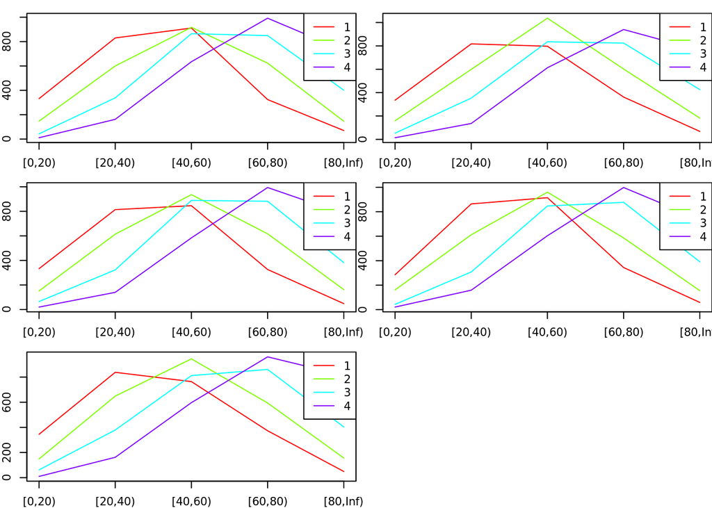

```r
years <- 1990:1994
ages <- unique(aldist_f_surv$age)

par(mfrow=c(ceiling(length(years) / 2), 2), mar = c(2,2,1,0))
for (y in years) g3_array_plot(xtabs(number ~ length + age + year, aldist_f_surv)[,,as.character(y)])
```

#### Fleet definition

A fleet, `f_surv`, is defined in much the same way as our stock above, however with a different set of actions:

```r
# Create fleet definition for f_surv ####################
f_surv <- g3_fleet("f_surv") |> g3s_livesonareas(area_names["IXa"])
```

We define the stock with `g3_fleet()` instead of `g3_stock()`, as a fleet isn’t divided into length or age bins. Simiarly, `g3s_age()` to divide into age bins isn’t relevant.

```r
actions_f_surv <- list(
  g3a_predate_fleet(
    f_surv,
    list(fish),
    suitabilities = g3_suitability_exponentiall50(),
    catchability_f = g3a_predate_catchability_totalfleet(
      g3_timeareadata("landings_f_surv", landings_f_surv, "weight", areas = area_names))),
  NULL)
actions <- c(actions, actions_f_surv)
```

The only action of `f_surv` is to predate `fish`. We define this with `g3a_predate_fleet()`, setting:

- *suitabilities*: This defines a predator’s preference for stocks. In this case we use `g3_suitability_exponentiall50()` a logarithmic dependence on the difference between length of individuals to $l_{50}$, the length of prey with a 50% probability of predation
- *catchability_f*: This controls a predator’s catch/effort. In this case we use `g3a_predate_catchability_totalfleet()` to define effort based on total biomass caught, and `g3_timeareadata()` to provide a timeseries table of landings data generated above

For other possible settings, follow the links to the function definitions.

Finally we define likelihood actions using `g3l_catchdistribution()`, to compare modelled catch against our length & age-length distribution data generated above.

```r
actions_likelihood_f_surv <- list(
  g3l_catchdistribution(
    "ldist_f_surv",
    obs_data = ldist_f_surv,
    fleets = list(f_surv),
    stocks = list(fish),
    function_f = g3l_distribution_sumofsquares(),
    area_group = area_names,
    report = TRUE,
    nll_breakdown = TRUE),
  g3l_catchdistribution(
    "aldist_f_surv",
    obs_data = aldist_f_surv,
    fleets = list(f_surv),
    stocks = list(fish),
    function_f = g3l_distribution_sumofsquares(),
    area_group = area_names,
    report = TRUE,
    nll_breakdown = TRUE),
  NULL)
actions <- c(actions, actions_likelihood_f_surv)
```

`function_f` defines the method of comparison between modelled catch & observation data, once aggregation has been done. `g3l_distribution_sumofsquares()` in this case compares the sum of squared difference. For more options on what to use here, follow the links to the reference.

To add futher fleets to your model, just repeat the same code with a different fleet name.

### Survey indices

Measures of abudnance, such as commercial CPUE data, can be added as observation data by adding `g3l_abundancedistribution()` likelihood actions:

```r
# Create abundance index for si_cpue ########################

# Generate random data
expand.grid(year = 1990:2023, step = 3, area = 'IXa') |>
    # Fill in a weight column with total biomass for the year/step/area combination
    mutate(weight = runif(n(), min = 10000, max = 100000)) ->
    dist_si_cpue

actions_likelihood_si_cpue <- list(

  g3l_abundancedistribution(
    "dist_si_cpue",
    dist_si_cpue,

    stocks = list(fish),
    function_f = g3l_distribution_surveyindices_log(alpha = NULL, beta = 1),
    area_group = area_names,
    report = TRUE,
    nll_breakdown = TRUE),
  NULL)

actions <- c(actions, actions_likelihood_si_cpue)
```

We create a `data.frame()` with *year*/*step*/*area*/*weight* columns, and input this into a likelihood action as before with our fleet.

The key differences between the catch distribution above are:

- We are using `g3l_abundancedistribution()` instead of `g3l_catchdistribution()`, which compares model abundance instead of catch from a fleet.
- Our observation data has a *weight* column instead of *number*. This results in us comparing total biomass, instead of number of individuals.
- We use `g3l_distribution_surveyindices_log()` to perform linear regression to calculate likelihood score. We have fixed beta (the slope) of the regression, only alpha will be estimated. We could reverse this, or estimate both by setting to NULL.

### Creating model functions and Parameterization

At this point, we are ready to convert our model into code:

```r
# Create model objective function ####################

# Apply bounds in code - the other option would be using control = list(lower = g3_tmb_lower(params.in), ...)
model_code <- g3_to_tmb(c(actions, list(
    g3a_report_detail(actions),
    g3l_bounds_penalty(actions) )))
```

`g3_to_tmb()` will take our list of actions and convert it into C++ code suitable for use with TMB.

`g3a_report_detail()` and `g3l_bounds_penalty()` add further actions to the model, based on the actions already within it:

- `g3a_report_detail()`: Adds abundance / catch reporting suitable for use with `gadgetutils::g3_fit()` and `gadgetplots::gadget_plots()`
- `g3l_bounds_penalty()`: Adds a large likelihood penalty for any parameter straying outside the lower/upper bounds. This allows us to use the lower/upper bounds for parameters with optimising methods that don’t support them natively.

To be able to run this model, we need to provide values (or initial guesses) for parameters. Earlier we used `g3_to_r()` and saw the resultant parameter template. With `g3_to_tmb()` we can do the same, however the template is more complex:

```r
simple_code <- g3_to_tmb(list(
    g3a_time(1990, 1991),
    g3a_naturalmortality(fish) ))
attr(simple_code, 'parameter_template')
```

```
##                      switch type value optimise random lower upper parscale
## retro_years     retro_years          0    FALSE  FALSE    NA    NA       NA
## fish.M.1           fish.M.1          0    FALSE  FALSE    NA    NA       NA
## fish.M.2           fish.M.2          0    FALSE  FALSE    NA    NA       NA
## fish.M.3           fish.M.3          0    FALSE  FALSE    NA    NA       NA
## fish.M.4           fish.M.4          0    FALSE  FALSE    NA    NA       NA
## fish.M.5           fish.M.5          0    FALSE  FALSE    NA    NA       NA
## project_years project_years          0    FALSE  FALSE    NA    NA       NA
##                                 source
## retro_years                   g3a_time
## fish.M.1      g3a_naturalmortality_exp
## fish.M.2      g3a_naturalmortality_exp
## fish.M.3      g3a_naturalmortality_exp
## fish.M.4      g3a_naturalmortality_exp
## fish.M.5      g3a_naturalmortality_exp
## project_years                 g3a_time
```

The TMB parameter template has the following columns:

- *switch*: The parameter name
- *type*: A colon-separtated list of keywords describing the behaviour of the parameter
  - `LOG`: Value will be converted to log-space inside the model, and back after optimisation
- *value*: The initial value for this parameter
- *optimise*: Should this parameter be optimised or fixed
- *random*: Should random effects be applied to this parameter? See `vignette('random-effects')`
- *lower*: A lower bound for this parameter
- *upper*: An upper bound for this parameter
- *parscale*: Relative scale for this parameter vs. others
- *source*: The action in which the parameter was defined. Look at the help for this function for more information on what the parameter does

The model is expecting 5 parameters, `fish.M.1` to `fish.M.5`, for each age group. We can either fix these to known values, or configure bounds to optimise within.

Filling in individual values can be tedious. The helper, `g3_init_val()`, will assist in filling in these values for you. Instead of setting individual values we can assign values using wildcard characters `*`, `#` (numeric), `|` (or):

```r
attr(simple_code, "parameter_template") |>
    g3_init_val("*.M.#", 0.1) |>
    g3_init_val("*.M.3", 0.5) |>
    g3_init_val("*.M.2|4", 0.2)
```

```
##                      switch type value optimise random lower upper parscale
## retro_years     retro_years          0    FALSE  FALSE    NA    NA       NA
## fish.M.1           fish.M.1        0.1    FALSE  FALSE    NA    NA       NA
## fish.M.2           fish.M.2        0.2    FALSE  FALSE    NA    NA       NA
## fish.M.3           fish.M.3        0.5    FALSE  FALSE    NA    NA       NA
## fish.M.4           fish.M.4        0.2    FALSE  FALSE    NA    NA       NA
## fish.M.5           fish.M.5        0.1    FALSE  FALSE    NA    NA       NA
## project_years project_years          0    FALSE  FALSE    NA    NA       NA
##                                 source
## retro_years                   g3a_time
## fish.M.1      g3a_naturalmortality_exp
## fish.M.2      g3a_naturalmortality_exp
## fish.M.3      g3a_naturalmortality_exp
## fish.M.4      g3a_naturalmortality_exp
## fish.M.5      g3a_naturalmortality_exp
## project_years                 g3a_time
```

Setting lower & upper bounds automatically turns on optimise, and fills in parscale:

```r
attr(simple_code, "parameter_template") |>
    g3_init_val("*.M.#", 0.15, lower = 0.001, upper = 1)
```

```
##                      switch type value optimise random lower upper parscale
## retro_years     retro_years          0    FALSE  FALSE    NA    NA       NA
## fish.M.1           fish.M.1       0.15     TRUE  FALSE 0.001     1    0.999
## fish.M.2           fish.M.2       0.15     TRUE  FALSE 0.001     1    0.999
## fish.M.3           fish.M.3       0.15     TRUE  FALSE 0.001     1    0.999
## fish.M.4           fish.M.4       0.15     TRUE  FALSE 0.001     1    0.999
## fish.M.5           fish.M.5       0.15     TRUE  FALSE 0.001     1    0.999
## project_years project_years          0    FALSE  FALSE    NA    NA       NA
##                                 source
## retro_years                   g3a_time
## fish.M.1      g3a_naturalmortality_exp
## fish.M.2      g3a_naturalmortality_exp
## fish.M.3      g3a_naturalmortality_exp
## fish.M.4      g3a_naturalmortality_exp
## fish.M.5      g3a_naturalmortality_exp
## project_years                 g3a_time
```

We can also use spread as a shorthand for `lower = value * (1 - spread), upper = value * (1 + spread)`:

```r
attr(simple_code, "parameter_template") |>
    g3_init_val("*.M.#", 0.15, spread = 0.5)
```

```
##                      switch type value optimise random lower upper parscale
## retro_years     retro_years          0    FALSE  FALSE    NA    NA       NA
## fish.M.1           fish.M.1       0.15     TRUE  FALSE 0.075 0.225     0.15
## fish.M.2           fish.M.2       0.15     TRUE  FALSE 0.075 0.225     0.15
## fish.M.3           fish.M.3       0.15     TRUE  FALSE 0.075 0.225     0.15
## fish.M.4           fish.M.4       0.15     TRUE  FALSE 0.075 0.225     0.15
## fish.M.5           fish.M.5       0.15     TRUE  FALSE 0.075 0.225     0.15
## project_years project_years          0    FALSE  FALSE    NA    NA       NA
##                                 source
## retro_years                   g3a_time
## fish.M.1      g3a_naturalmortality_exp
## fish.M.2      g3a_naturalmortality_exp
## fish.M.3      g3a_naturalmortality_exp
## fish.M.4      g3a_naturalmortality_exp
## fish.M.5      g3a_naturalmortality_exp
## project_years                 g3a_time
```

This allows us to fill in parameters without worrying too much about stock/fleet naming:

```r
# Guess l50 / linf based on stock sizes
estimate_l50 <- g3_stock_def(fish, "midlen")[[length(g3_stock_def(fish, "midlen")) / 2]]
estimate_linf <- max(g3_stock_def(fish, "midlen"))
estimate_t0 <- g3_stock_def(fish, "minage") - 0.8

attr(model_code, "parameter_template") |>
  # fish.init.scalar & fish.rec.scalar: Overall scalar for recruitment/initial conditions, see g3a_renewal_normalcv()
  g3_init_val("*.rec|init.scalar", 1, optimise = FALSE) |>
  # fish.rec.(age): Per-age recriutment scalar, see g3a_renewal_normalcv()
  g3_init_val("*.init.#", 10, lower = 0.001, upper = 30) |>
  # fish.rec.(year): Recruitment level year-on-year, see g3a_renewal_normalcv()
  g3_init_val("*.rec.#", 1e-4, lower = 1e-6, upper = 1e-2) |>
  g3_init_val("*.rec.proj", 0.002) |>
  # init.F: Offset for initial M, see g3a_renewal_initabund()
  g3_init_val("init.F", 0.5, lower = 0.1, upper = 1) |>

  # fish.M.(age): per-age M for our species, see g3a_naturalmortality()
  g3_init_val("*.M.#", 0.15, lower = 0.001, upper = 10) |>

  # fish.Linf, fish.K, fish.t0: VonB parameters for our species, see g3a_renewal_vonb_t0(), g3a_grow_lengthvbsimple()
  g3_init_val("*.Linf", estimate_linf, spread = 0.2) |>
  g3_init_val("*.K", 0.3, lower = 0.04, upper = 1.2) |>
  g3_init_val("*.t0", estimate_t0, spread = 2) |>

  # fish.walpha, fish.wbeta: Age/weight relationship for initialconditions, renewal, see g3a_renewal_normalcv()
  g3_init_val("*.walpha", 0.01, optimise = FALSE) |>
  g3_init_val("*.wbeta", 3, optimise = FALSE) |>

  # fish.f_surv.alpha, fish.f_surv.l50: Curve/l50 for fishing suitability, see g3_suitability_exponentiall50()
  g3_init_val("*.*.alpha", 0.07, lower = 0.01, upper = 0.2) |>
  g3_init_val("*.*.l50", estimate_l50, spread = 0.25) |>

  # fish.bbin: Beta for beta-binomial distribution for fish growth, see g3a_grow_impl_bbinom()
  g3_init_val("*.bbin", 1, lower = 1e-05, upper = 10) |>

  # identity() is a do-nothing function, but it lets us finish on a new line
  identity() -> params.in
```

Finally we are ready for optimisation runs. `g3_tmb_adfun()` is a wrapper around `TMB::MakeADFun()` and `TMB::compile`, producing a TMB *objective function*. `gadgetutils::g3_iterative()` then optimises based on iterative reweighting

```r
# Optimise model ################################
obj.fn <- g3_tmb_adfun(model_code, params.in)

params.out <- gadgetutils::g3_iterative(getwd(),
    wgts = "WGTS",
    model = model_code,
    params.in = params.in,
    grouping = list(
        fleet = c("ldist_f_surv", "aldist_f_surv"),
        abund = c("dist_si_cpue")),
    method = "BFGS",
    control = list(maxit = 1000, reltol = 1e-10),
    cv_floor = 0.05)
```

Once this has finished, we can view the output using `gadgetplots::gadget_plots()`.

```r
# Generate detailed report ######################
fit <- gadgetutils::g3_fit(model_code, params.out)
gadgetplots::gadget_plots(fit, "figs", file_type = "html")
```

Once finished, you can view the output in your web browser:

```r
utils::browseURL("figs/model_output_figures.html")
```